# Normalization of the Mass Spec Data

# Comparison

## Visualizations

### Non-Imputed

**TRANSFORMATIONS**

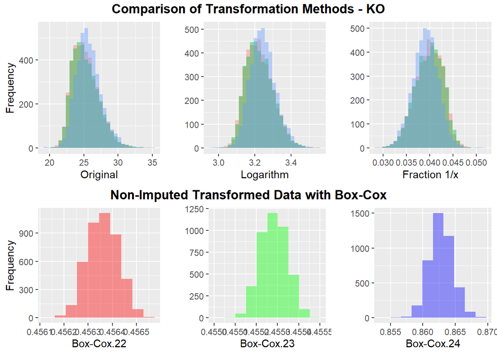

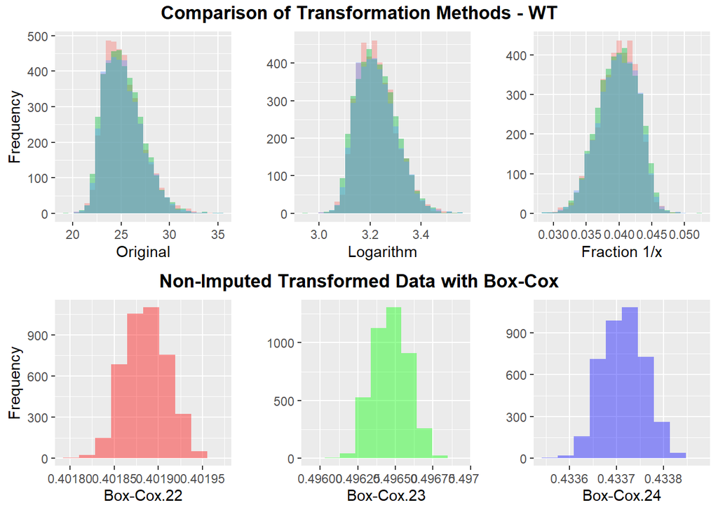

**NORMALIZATIONS**

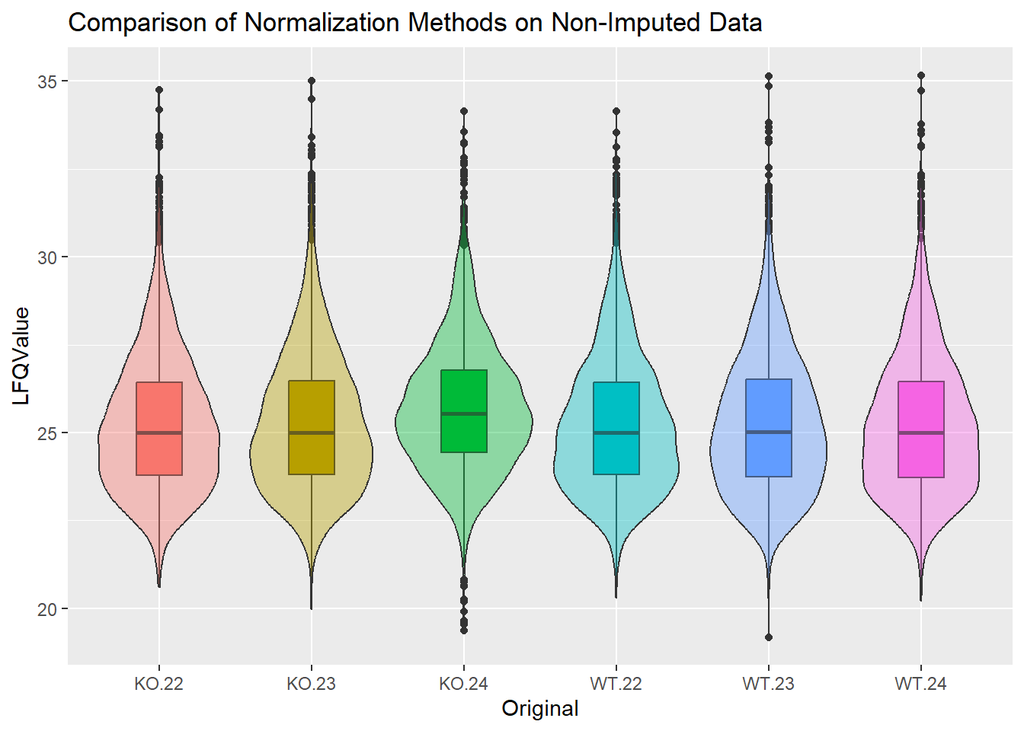

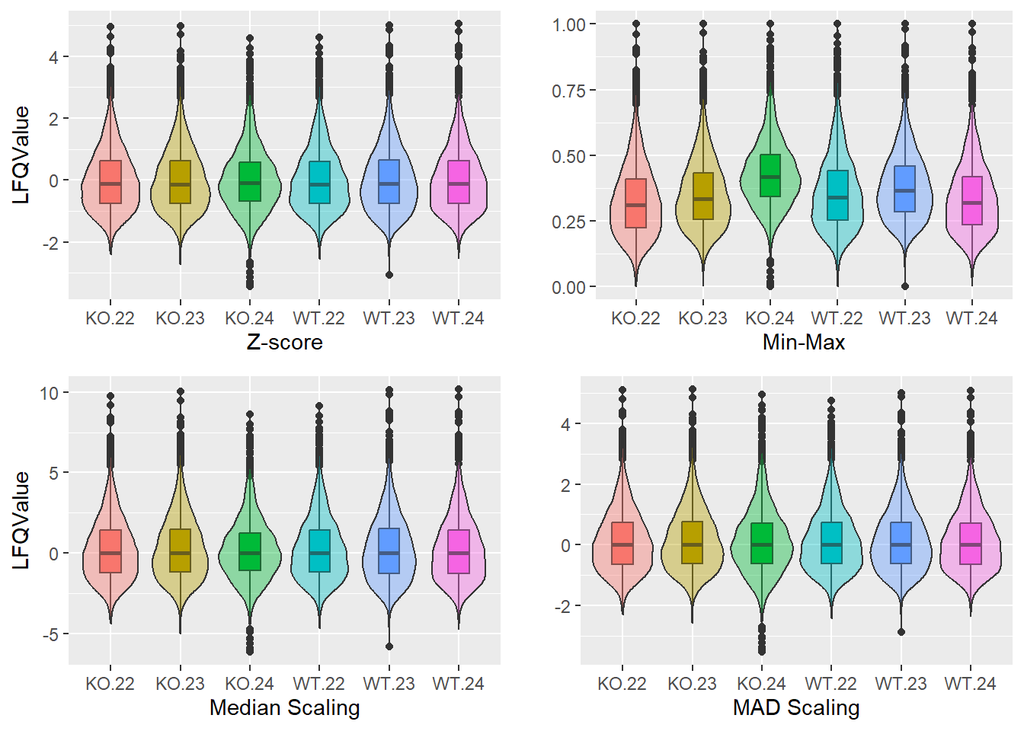

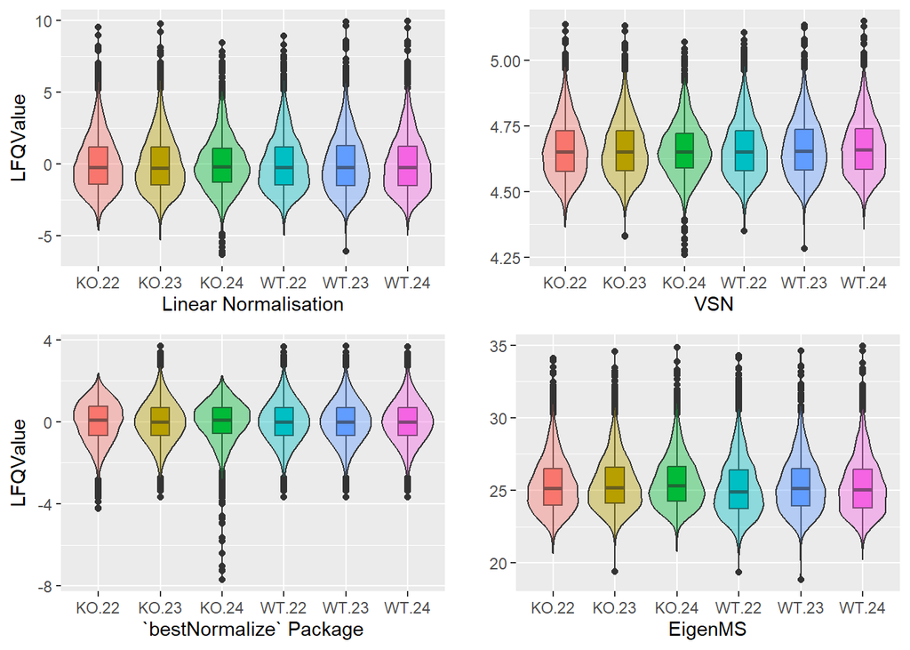

**HISTOGRAMS**

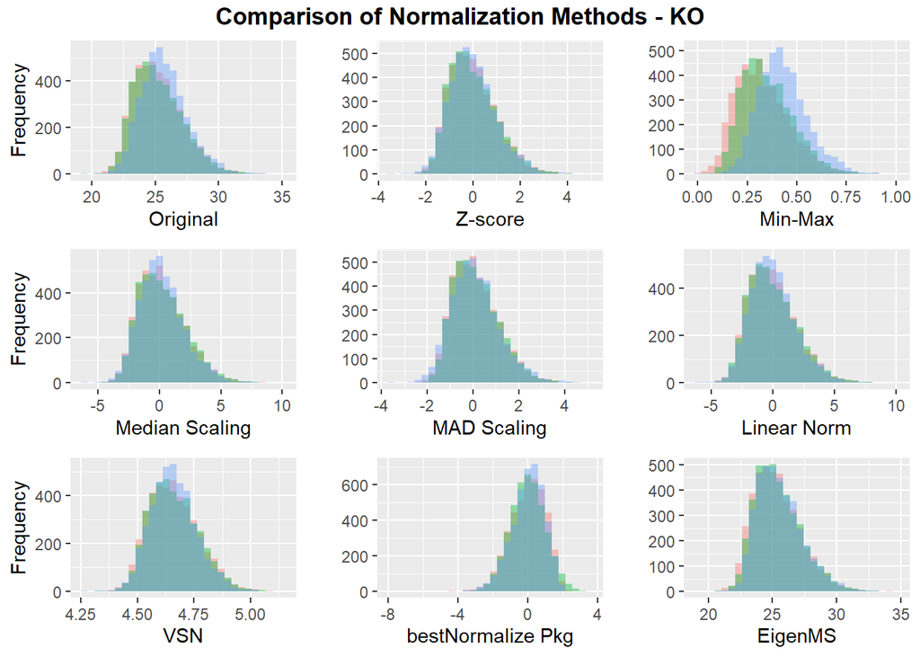

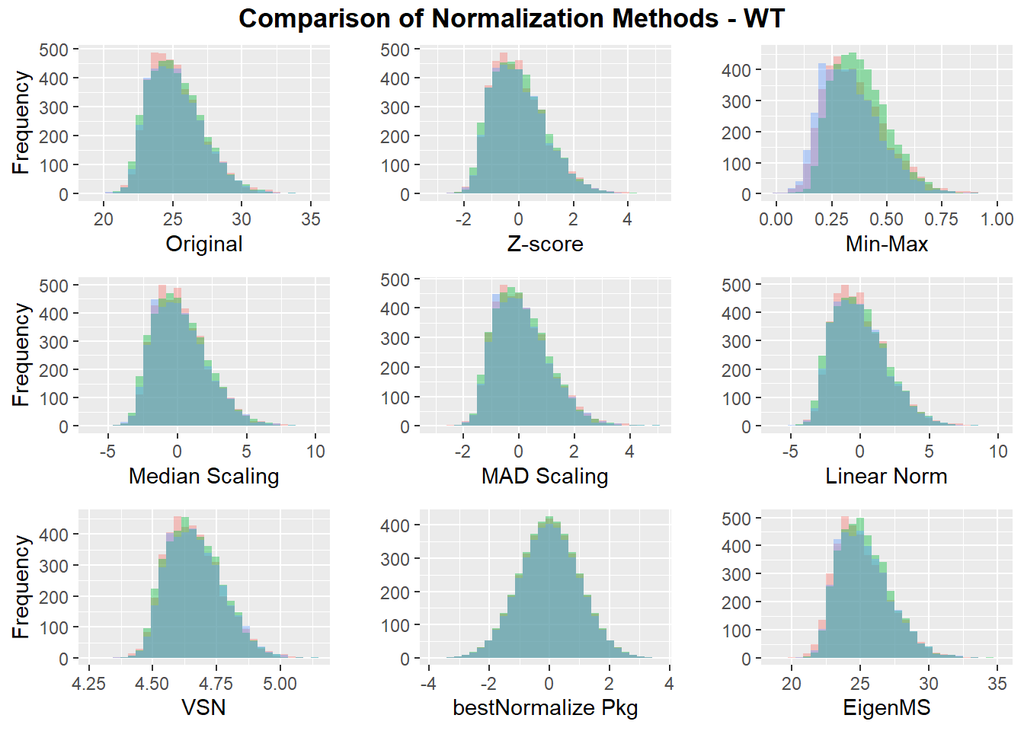

### Imputed

**TRANSFORMATIONS**

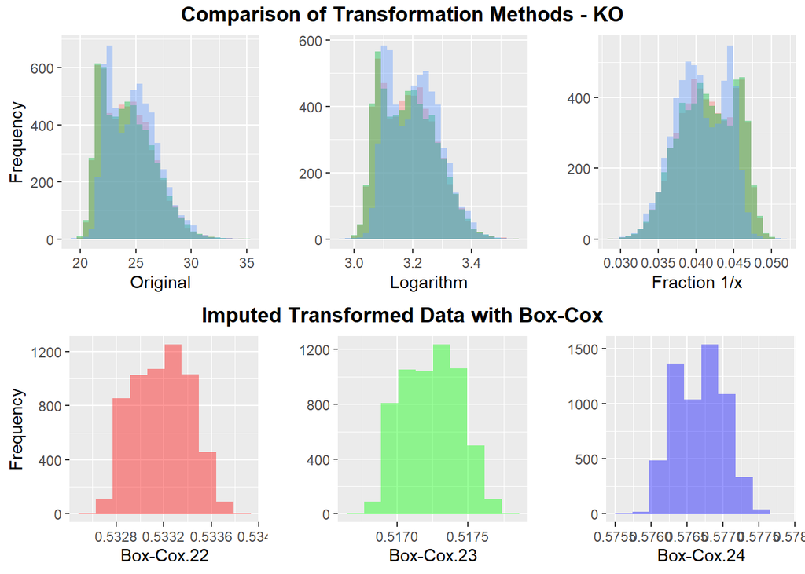

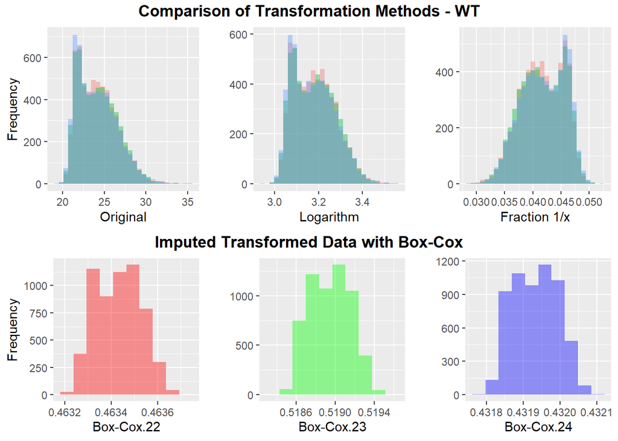

**NORMALIZATIONS**

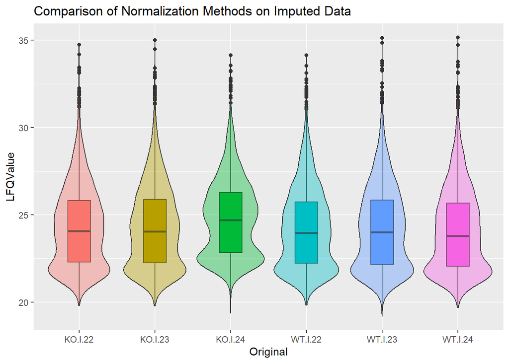

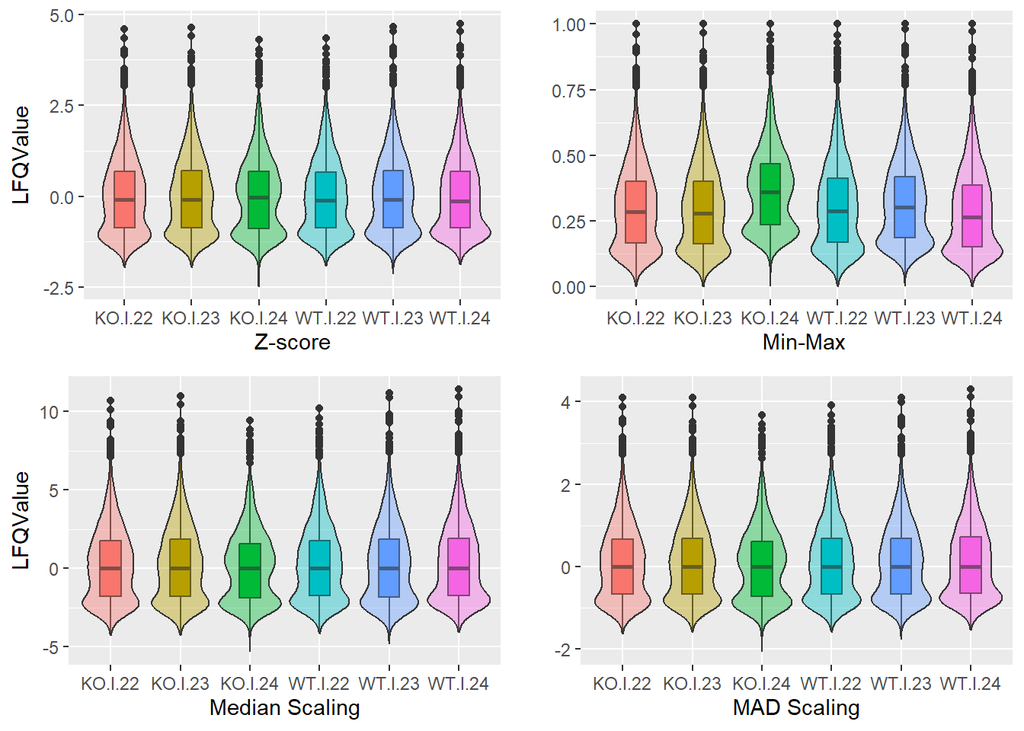

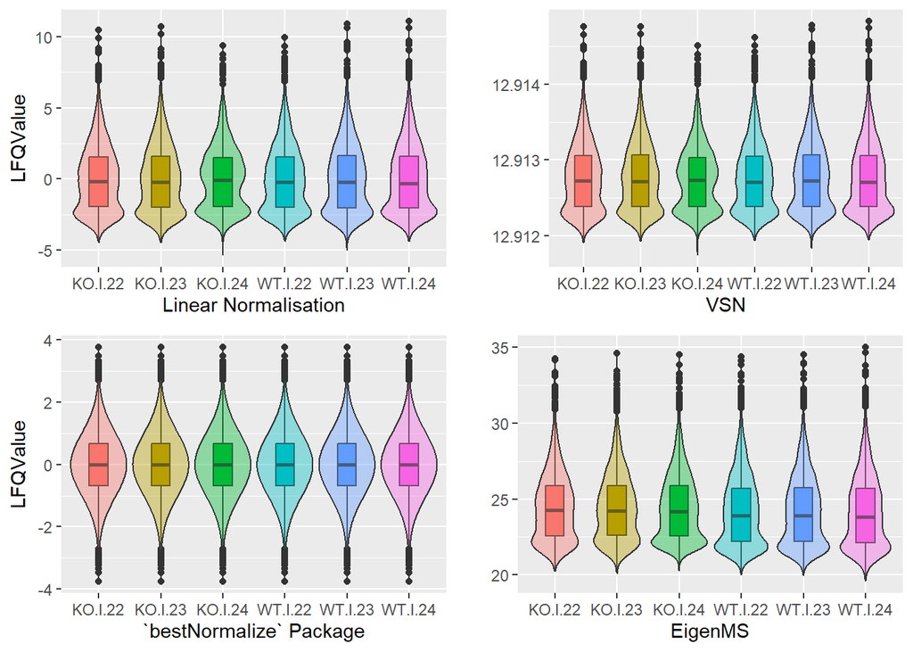

**HISTOGRAMS**

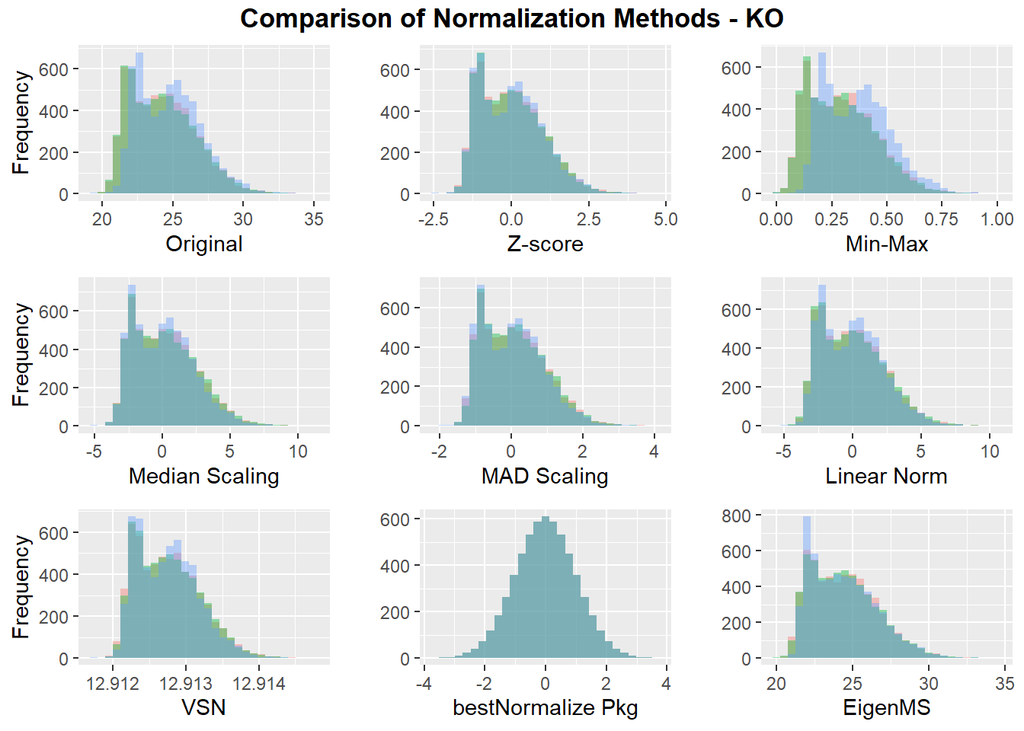

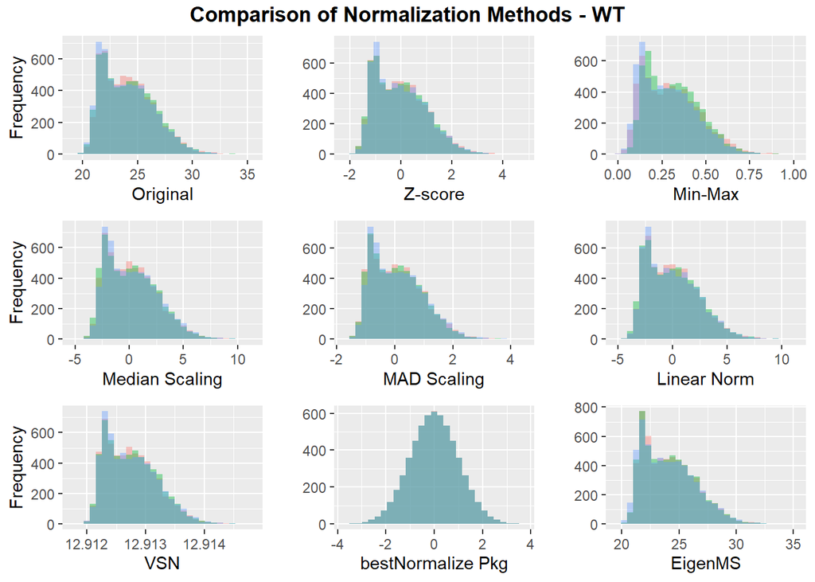

## Statistical Metrics

**COEFFICIENT OF VARIATION (CV) / RELATIVE STANDARD DEVIATION (RSD)**

This is a way to measure how spread out values are in a dataset relative to the mean. A lower RSD/CV indicates better normalization. It is calculated as:

$CV = \frac{\sigma}{\mu}$

where:

- $\sigma$: The standard deviation of dataset
- $\mu$: The mean of dataset

### Non-Imputed CV

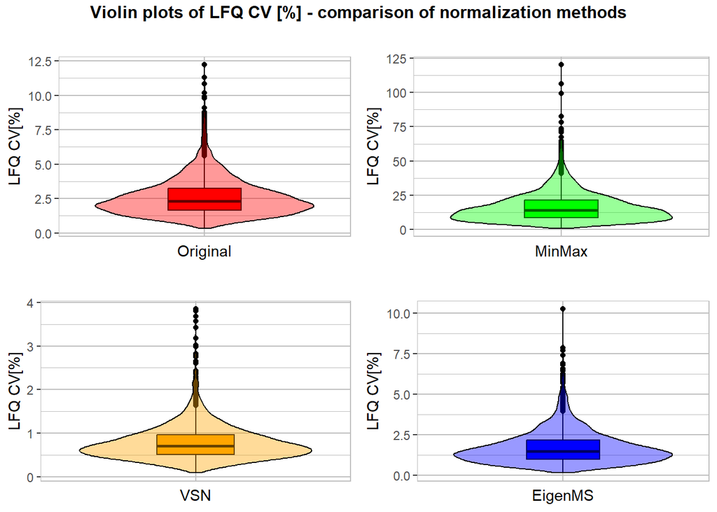

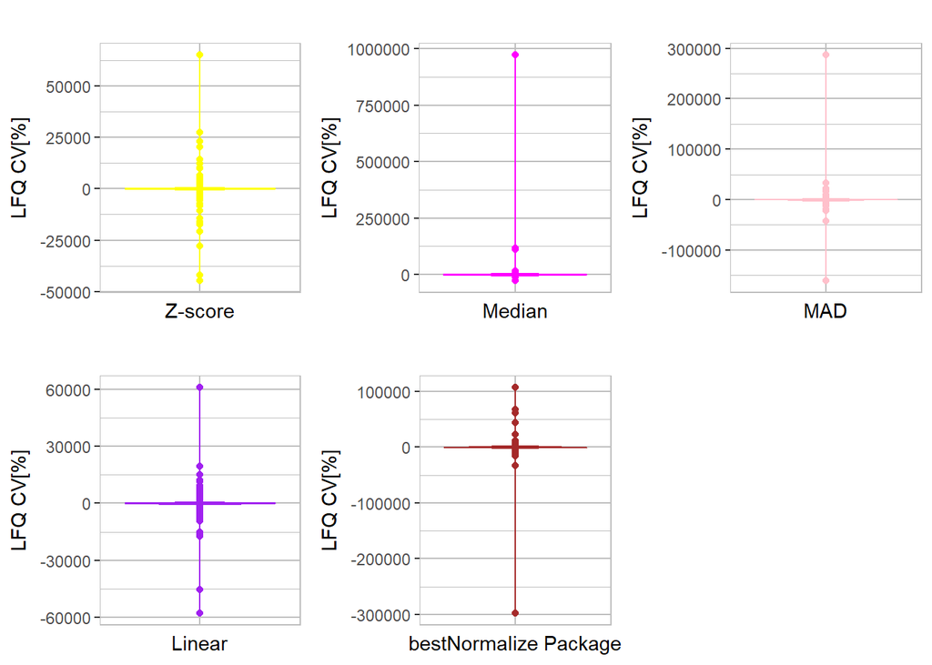

**SUMMARY OF COEFFICIENT OF VARIATION**

| method | mean | median | sd |
| --- | --- | --- | --- |
| Before | 2.60345 | 2.32108 | 1.36294 |
| Linear | -23.16509 | 7.96575 | 1880.47057 |
| MAD | 27.04635 | 14.30998 | 5821.04138 |
| Median | 374.34571 | 14.51299 | 16928.57389 |
| MinMax | 16.43886 | 14.12972 | 10.90711 |
| VSN | 0.77984 | 0.70280 | 0.40245 |
| Z-score | -26.97006 | 8.23273 | 2015.82249 |
| bestNormalize | -29.66534 | 14.24819 | 5800.46260 |
| cv.eig | 1.71161 | 1.48327 | 1.02641 |

As we can see above, the best methods were:

- Min-Max Normalization
- VSN
- EigenMS

Coefficient of Variation for the rest of the methods have a poor performance.

### Imputed CV

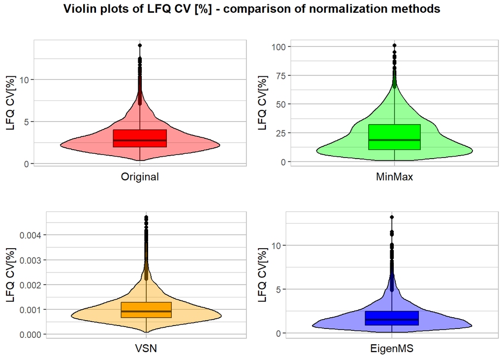

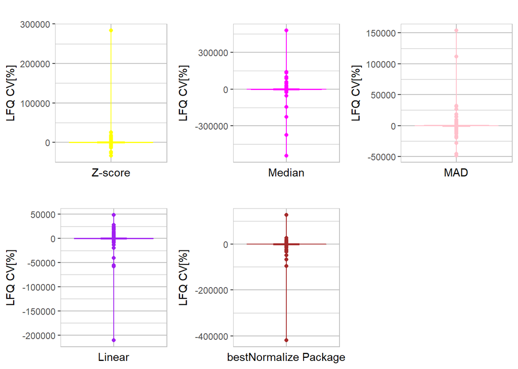

**SUMMARY OF COEFFICIENT OF VARIATION**

| method | mean | median | sd |
| --- | --- | --- | --- |
| Before | 3.15546 | 2.76909 | 1.72972 |
| Linear | -40.60882 | -15.66301 | 3209.98775 |
| MAD | 32.00215 | -11.75170 | 2871.42838 |
| Median | -49.60885 | -11.88139 | 11731.96962 |
| MinMax | 22.49715 | 18.90094 | 15.24646 |
| VSN | 0.00105 | 0.00093 | 0.00056 |
| Z-score | 27.77224 | -15.72619 | 3846.88633 |
| bestNormalize | -109.23190 | -23.18979 | 6047.58640 |
| cv_imp.eig | 1.90720 | 1.55418 | 1.38867 |

**REPRODUCIBILITY OF BIOLOGICAL REPLICATES**

After normalization, biological replicates should group more tightly. You can assess this by measuring the intraclass correlation coefficient (ICC) to see if replicates cluster together.

A guidelines for interpretation by [Koo and Li (2016)](https://doi.org/10.1016%2Fj.jcm.2016.02.012):

- below 0.50: poor
- between 0.50 and 0.75: moderate
- between 0.75 and 0.90: good
- above 0.90: excellent

### Non-Imputed ICC

|  | ICC |
| --- | --- |
| Before | 0.8506696 |
| Z-score | 0.8556525 |
| MinMax | 0.8556525 |
| Median | 0.8571659 |
| MAD | 0.8517825 |
| Linear | 0.8576953 |
| VSN | 0.8485755 |
| bestNormalize | 0.7953859 |
| EigenMS | 0.9259821 |

### Imputed ICC

|  | ICC |
| --- | --- |
| Before | 0.8620635 |
| Z-score | 0.8707454 |
| MinMax | 0.8707454 |
| Median | 0.8706236 |
| MAD | 0.8703144 |
| Linear | 0.8716954 |
| VSN | 0.8717091 |
| bestNormalize | 0.8030002 |
| EigenMS | 0.9376567 |

# Conclusion

The method chosen with `bestNormalize` gave us a perfect shape of a distribution, but we lost the main differences between samples. In my opinion the best result gave the **Eigen Normalization** method, because this method kept a characteristic of a sample and this is very important in the analysis of biological data.

# References

1. [A systematic evaluation of normalization methods in quantitative label-free proteomics](https://academic.oup.com/bib/article/19/1/1/2562889)
2. [bestNormalize R Package](https://cran.r-project.org/web/packages/bestNormalize/vignettes/bestNormalize.html#the-ordered-quantile-technique)
3. [How to Normalize Data in R for my Data: Methods and Examples](https://rpubs.com/zubairishaq9/how-to-normalize-data-r-my-data)
4. [EigenMS](https://sourceforge.net/projects/eigenms/)
5. [Normalization of peak intensities in bottom-up MS-based proteomics using singular value decomposition](https://pubmed.ncbi.nlm.nih.gov/19602524/)